# Final Project Bio 316

Adam Ziegler

7/17/2020

## Comparing Migration Patterns of Striped Bass (*Morone saxatilis*) and Menhaden (*Brevoortia tyrannus*)

### Looking at Changes in Bathymetry, Temperature, and Latitude Preferences Amongst Both Species During 2007-2020 Compared to Historical Preference (1953-2007)

## Research Question

Have recent changes in the climate caused a change in the migration pattern of either Striped Bass or Menhaden? Furthermore, have striped bass lessened its following of the Menhaden and possibly created resident populations?

Striped bass is a very popular game fish species in the North East, with menhaden being a primary food supply. It has been found that Menhaden produce a cyclic movement from North to South, spending the summer in waters north of Cape Cod and begin a migration southward reaching North Carolina in November (Nicholson). The striped bass can follow this food supply throughout the year, hence following the same migration pattern as the menhaden. It is known that some striped bass, such as those studied in the Delaware Bay, remain close to river mouths, and follow the tides in and out of the river. These fish were only recorded over a 140 hour period, and therefore do not fully display relations to menhaden (Tupper & Able). However, it opens the possibility that populations of striped bass are moving away from the menhaden food source and establishing resident populations. A study focusing on striped bass in the Hudson river showed that three contingents existed inside of the studied population that had divergent migration patterns, with the larger adults migrating all the way into Cape Cod waters in the spring (Gahagan et al).

In this project I hope to:

- Download data files for each species and raster for temperature and bathymetry
- Create historical graphs to understand the preferred migration patterns
- Generate Year Intervals from 2007-2020 for each month to see newly established preferences

## Loading Necesaary Data And Libraries

Data files for both striped bass and Menhaden were dowloaded from GBIF. GBIF uses observational data of public recordings rather than a more accurate tagging program. Therefore the data has bias in human activity levels to manage recordings. Both temperature and bathymetry came from MARSPEC in the form of Google Drive files. In order to download this data, an active Google Drive account needs to be available.

```r
#Libraries Needed for this Project.
library(dplyr)
library(spocc)
library(ggplot2)
library(raster)
library(rgdal)
library(googledrive)

#Calling in Data for Striped Bass and Menhaden from GBIF

striped_bass = occ(query = "Morone saxatilis",
                  from= "gbif",
                  limit=3000,
                  has_coords=TRUE)  #limit set to 3000 to acquire many data points and eliminate chances of skewed data

menhaden = occ(query = "Brevoortia tyrannus",
                  from= "gbif",
                  limit=3000,
                  has_coords=TRUE) #limit set to 3000 to acquire many data points and eliminate chances of skewed data

#Calling in Raster Data from a MARSPEC Google Drive File for Temperature and Bathymetry

dl_1 <- drive_download(
  as_id("0BzY4i8pEFYeQenc0R0lQNTdQWkk"), path = 'temperature',
  overwrite = TRUE)
temperature = raster('temperature') #as_id is the portion of the URL when downloading that gave the exact id of the file at hand

dl_2 <- drive_download(
  as_id("0BzY4i8pEFYeQOVVoZ2JrVW9TdzA"), path = 'bathy',
  overwrite = TRUE)
bathymetry = raster('bathy')
```

## Modifications to the Dataframes to Create a More Organized Dataframe and Environment

The longitude and latitude column values for both species were converted to numeric values so they could be expressed as a continuous X-axis for the histograms. A species column was also created for each species data frame for easy recognition when combining the frames and showing values for each species separately on the same histogram. Latitude and Longitude were also converted to numeric values in order to be passed through the spatial points data frame later on.

```r
#Modifying Data Frames from Both Species to Select Columns Longitude, Latitude, Year, Month, and Species

#the following is a cleaning of the species data set by filtering only the wanted columns and renaming some of the columns for ease fos use

striped_bass_df<- data.frame(striped_bass$gbif$data)%>%
  dplyr::select(Morone_saxatilis.longitude, Morone_saxatilis.latitude,
         Morone_saxatilis.stateProvince, Morone_saxatilis.year,
         Morone_saxatilis.month, Morone_saxatilis.day)%>%
  rename( Month = "Morone_saxatilis.month") %>%
  rename(Year= "Morone_saxatilis.year") %>%
  mutate(Longitude = as.numeric(Morone_saxatilis.longitude)) %>%
  mutate(Latitude = as.numeric(Morone_saxatilis.latitude)) %>%
  na.omit() %>%
  group_by(Month) %>%
  mutate(Species = 'Morone saxatilis') %>%
  dplyr::select(Longitude, Latitude, Month, Year, Species)

menhaden_df<-data.frame(menhaden$gbif$data) %>%
  dplyr::select(Brevoortia_tyrannus.longitude, Brevoortia_tyrannus.latitude,
         Brevoortia_tyrannus.stateProvince, Brevoortia_tyrannus.year,
         Brevoortia_tyrannus.month, Brevoortia_tyrannus.day) %>%
  rename( Month = "Brevoortia_tyrannus.month") %>%
  rename(Year = "Brevoortia_tyrannus.year") %>%
  mutate(Longitude = as.numeric(Brevoortia_tyrannus.longitude)) %>%
  mutate(Latitude = as.numeric(Brevoortia_tyrannus.latitude)) %>%
  na.omit() %>%
  group_by(Month) %>%
  mutate(Species= 'Brevoortia tyrannus') %>%
  dplyr::select(Longitude, Latitude, Month, Year, Species)

#Both species data frames combined together to make a single dataframe

Both_species_df <- rbind(striped_bass_df, menhaden_df)
```

## Creating, Extracting, and Combining Rasters with Data Frame

In order to use the values of latitude created for the species, a spatial points data frame was generated, and also the rasters for both temperature and bathymetry were extracted using the same spatial data points. This would allow both the latitude and longitude values to be connected to actual values that could be applied to making images.

```r
#Create a Spatial Points Data Frame for Raster Extraction

points_crs = crs("+proj=longlat +datam=WGS84 +ellps=WGS84 +towgs84=0,0,0")

sp.points = SpatialPointsDataFrame(Both_species_df[,c('Longitude', 'Latitude')],Both_species_df,proj4string = points_crs)

#Extracting the Rasters from Downloaded Google Drive Files so they can be used in coordination with the species data frames.

temperature_extract <- extract(temperature, sp.points) %>%
  as.data.frame() %>%
  dplyr::select(temperature=".") #this line is because when downloading the files, the column name is given simply as ".", so to ease confusion it is renamed.

bathymetry_extract <- extract(bathymetry, sp.points) %>%
  as.data.frame() %>%
  dplyr::select(bathymetry=".")

#Combine extracted data with dataframe

whole_data <- cbind(temperature_extract, bathymetry_extract, Both_species_df)
```

## Creating Historical Histograms

It is important to be able to compare the data we are interested in (2007-2020) to the traditional migration patterns both species underwent. In order to do this, a subsection of the data was used (1953-2007) to create historic patterns of Latitude, Bathymetry, and Temperature preference for each month.

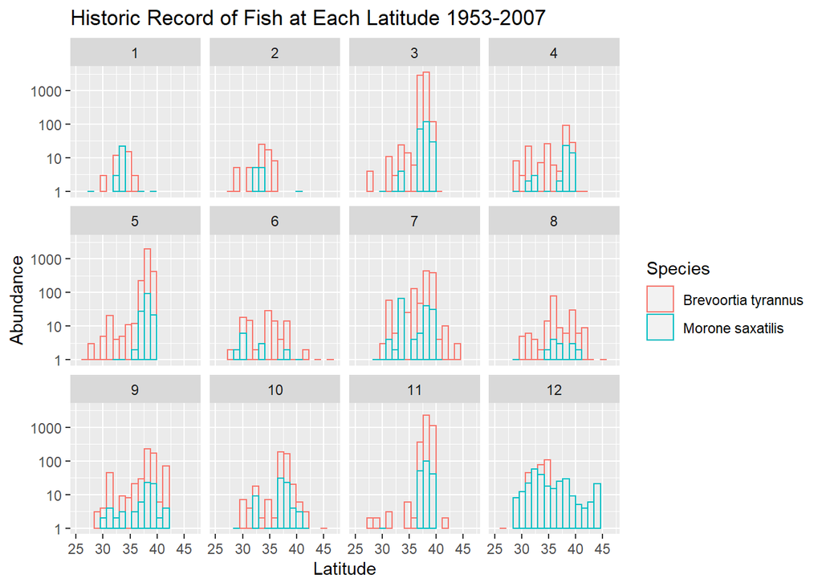

```r
#Historic Latitude Graphs (1953-2007)
Both_species_historic <- Both_species_df%>%
  filter(Year %in% (1953:2007))

Whole_data_historic <- whole_data%>%
  filter(Year%in% (1953:2007))

ggplot(data= Both_species_historic)+
  geom_histogram(aes(x= Latitude, color= Species),
                 fill = NA , bins = 20)+
  labs(title= 'Historic Record of Fish at Each Latitude 1953-2007',
       x = 'Latitude', y = 'Abundance')+
  scale_y_log10()+
  xlim(25,47)+
  facet_wrap(~Month)
```

```r
print('Histroic_Migration_Latitude')
```

```
## [1] "Histroic_Migration_Latitude"
```

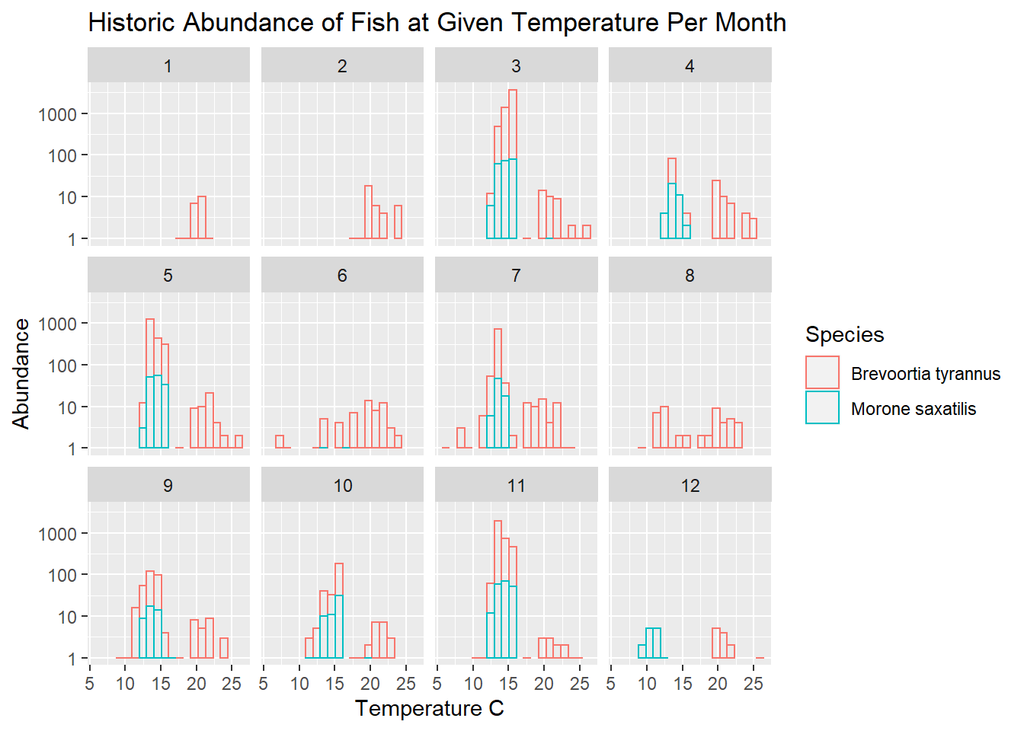

```r
#Historic Temperature Graphs (1953-2007)
ggplot(data= Whole_data_historic)+
  geom_histogram(aes(x= temperature/100, color = Species),
                 fill = NA, bins = 20)+
  labs(title= 'Historic Abundance of Fish at Given Temperature Per Month',
       x = 'Temperature C', y = 'Abundance')+
  scale_y_log10()+
  facet_wrap(~Month)
```

```r
print('Historic_Migration_Temp')
```

```
## [1] "Historic_Migration_Temp"
```

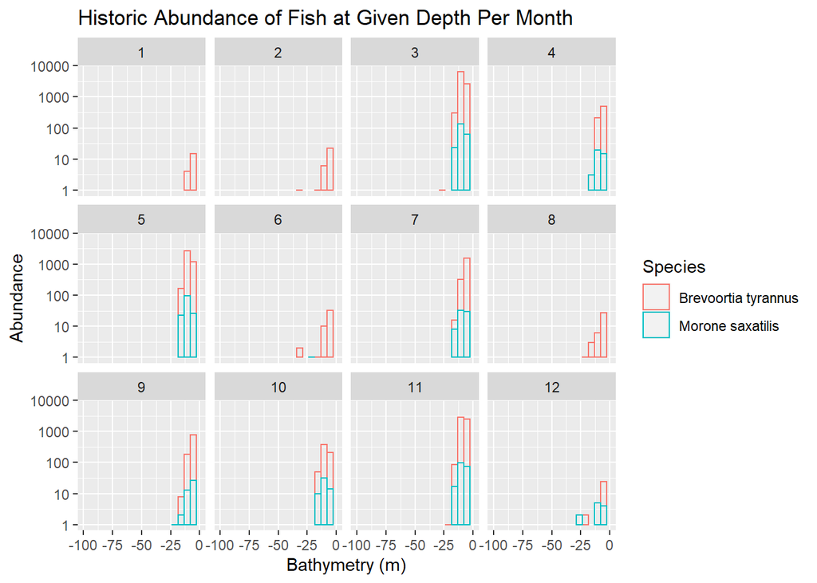

```r
#Historic Bathymetry Graphs (1953-2007)
ggplot(data= Whole_data_historic)+
  geom_histogram(aes(x= bathymetry, color = Species),
                 fill = NA, bins = 20)+
  labs(title= 'Historic Abundance of Fish at Given Depth Per Month',
       x = 'Bathymetry (m)', y = 'Abundance')+
  scale_y_log10()+
  xlim(-100,0)+
  facet_wrap(~Month)
```

```r
print('Historic_Migration_Bathymetry')
```

```
## [1] "Historic_Migration_Bathymetry"
```

These Three graphs each display the historical preferences that both species displayed during the later half of the 20th century and the early 21st century. These graphs will be used as a baseline behavior for the new year intervals to see if any form of climate change has played a large effect on either species migration pattern.

## Creating Intervals To Observe Changes in Migration

Now that the historical data has been graphed, the new migration patterns need to be graphed. In order to get the most out of the data, sub-setting it into three year intervals can provide a better understanding of changes either fish species might have adapted. If 2007-2020 were all graphed on a single histogram then any patterns that slowly evolved would be hidden. In order to create these chunks, the cut() function was applied to the Year column in the data frame.

```r
#
Year_cut<- cut(whole_data$Year, breaks = c(2007,2010,2013,2016,2020))

whole_data_mutated <- mutate(whole_data,Year_cut=Year_cut)%>% na.omit()
```

## Creating Histograms for the Year Intervals

Now that the Year has been modified to be spliced into three year intervals, this data can be taken and placed inside of ggplot to how the migration changes over Latitude, Temperature, and Bathymetry. The following code takes the whole_data_mutated frame generated earlier, and makes a graph for each variable.

[figure not shown]

```r
#Year Interval Graphs for Latitude Preference Among Both Species #(2007-2020)
ggplot(whole_data_mutated)+
  geom_histogram(
    aes(x= Latitude, color= Species),
    fill = NA , bins = 20)+
  labs(x = 'Latitude', y = 'Abundance')+
  ggtitle(paste('Fish Abundance at Latitude For Month Over Year Intervals \n'))+
  scale_y_log10()+
  xlim(25,47)+
  facet_wrap(~Year_cut + Month)
```

[figure not shown]

```r
ggsave('Latitude_Over_Year_Intervals.png', width = 15, height = 9)

#Creating an Iteration Pattern to Show Temperature Preference
#Graph for Year Intervals Per Month (2007-2020)

ggplot(whole_data_mutated)+
  geom_histogram(
    aes(x= temperature/100, color= Species),
    fill = NA , bins = 20)+
  labs(x = 'Temperature', y = 'Abundance')+
  ggtitle('Fish Abundance at Each Temperature Over Year Intervals \n')+
  scale_y_log10()+
  facet_wrap(~Year_cut + Month)
```

[figure not shown]

```r
ggsave('Temperature_Over_Year_Intervals.png', width = 15, height = 9)

#Creating an Iteration Pattern to Show Bathymetry Preference
#Graph for Year Intervals Per Month (2007-2020)

ggplot(whole_data_mutated)+
  geom_histogram(
    aes(x= bathymetry, color= Species),
    fill = NA , bins = 20)+
  labs(x = 'Bathymetry', y = 'Abundance')+
  ggtitle('Fish Abundance at Each Depth Over Year Intervals \n')+
  scale_y_log10()+
  facet_wrap(~Year_cut + Month)
```

```r
ggsave('Bathymetry_Over_Year_Intervals.png', width = 15, height = 9)
```

These graphs display so much data that the code could not properly display their results through this html. However, using the code ggsave will place expanded photos of the graphs with readable data on your computer. Likewise, you can also reference the figures through the GitHub repository available at: https://github.com/AdamZigg/final_project_bio316 in the Figures Folder.

## Results

Galagen et al. found that seasonal movements of striped bass could be detected by acoustic telemetry in the Hudson River, and coincided with higher density detection from May to December, but low in January through April. When observing the Latitude Histogram for the Year Intervals, we see that the striped bass follow a similar pattern with lower densities of the fish being recorded in months March and April (3 and 4) at Latitude 40 (roughly the Hudson River’s Latitude). What is interesting to note is the high abundance of striped bass at month 11 of the 2010-2013 year range. Ideally the Menhaden (which are also high on that graph) would be closer to North Carolina, and not in the Hudson River area. This could be a resident population of both species that remain in Hudson’s more protected waters from harsher environments. A tagging program on Menhaden by Nicholson found that Menhaden tagged in the region of Cape Hatteras showed little movement either North or South from June to November. This could explain why such a high number of menhaden were present at Latitude 40 in November of 2010-2013. However, the complete absence of any menhaden the following month shows the variability in this type of data analysis. Instead of conducting true tagging like Nicholson and Galagen et al., this data was solely based off of recorded observations. Therefore, it is not to say that menhaden are not present at that time, but just were not observed.

It would be nice to continually look and update this data through the coming years to see if the next decade still falls in line with the historical data, or if a new pattern emerges.

## References

‘dplyr’ (Gahagan, Fox, and Secor 2015)

‘dplyr’ (Nicholson 1978)

‘dplyr’ (Rudershausen et al. 2005)

‘dplyr’ (Tupper and Able 2000)

Gahagan, Benjamin I, Dewayne A Fox, and David H Secor. 2015. “Partial Migration of Striped Bass: Revisiting the Contingent Hypothesis.” *Marine Ecology Progress Series* 525: 185–97.

Nicholson, William R. 1978. “Movements and Population Structure of Atlantic Menhaden Indicated by Tag Returns.” *Estuaries* 1 (3): 141–50.

Rudershausen, Paul J, Jack E Tuomikoski, Jeffrey A Buckel, and Joseph E Hightower. 2005. “Prey Selectivity and Diet of Striped Bass in Western Albemarle Sound, North Carolina.” *Transactions of the American Fisheries Society* 134 (5): 1059–74.

Tupper, M, and KW Able. 2000. “Movements and Food Habits of Striped Bass (Morone Saxatilis) in Delaware Bay (Usa) Salt Marshes: Comparison of a Restored and a Reference Marsh.” *Marine Biology* 137 (5-6): 1049–58.